# Analisis Popularitas dan Revenue Aktor pada Database Sakila

Fariska Ziadatun Ni’mah

2026-05-25

# Pendahuluan

Industri rental film memiliki banyak faktor yang memengaruhi popularitas suatu film, salah satunya adalah aktor yang membintangi film tersebut. Actor yang terkenal atau sering muncul pada film populer cenderung menarik lebih banyak pelanggan untuk melakukan rental film.

Pada analisis ini dilakukan pengamatan terhadap popularitas actor berdasarkan jumlah rental film serta total revenue yang dihasilkan menggunakan database Sakila.

# Tujuan Analisis

1. Menentukan actor paling populer berdasarkan jumlah rental.
2. Menentukan actor dengan revenue tertinggi.
3. Menganalisis hubungan jumlah film actor dengan popularitas rental.

# Library

```r
library(DBI)
library(RMySQL)
library(tidyverse)
library(ggplot2)
library(plotly)
library(DT)
```

# Koneksi Database

```r
con <- dbConnect(
  RMySQL::MySQL(),
  dbname = "sakila",
  host = "localhost",
  port = 3306,
  user = "root",
  password = "r0vErk41xoxo"
)
```

# Pengambilan Data

```r
query <- "
SELECT
    CONCAT(a.first_name, ' ', a.last_name) AS actor_name,
    COUNT(r.rental_id) AS total_rental,
    COUNT(DISTINCT f.film_id) AS total_film,
    ROUND(SUM(p.amount),2) AS total_revenue
FROM actor a
JOIN film_actor fa
    ON a.actor_id = fa.actor_id
JOIN film f
    ON fa.film_id = f.film_id
JOIN inventory i
    ON f.film_id = i.film_id
JOIN rental r
    ON i.inventory_id = r.inventory_id
JOIN payment p
    ON r.rental_id = p.rental_id
GROUP BY actor_name
ORDER BY total_rental DESC
"

actor_data <- dbGetQuery(con, query)
head(actor_data)
```

```
##           actor_name total_rental total_film total_revenue
## 1        SUSAN DAVIS          825         53       3538.74
## 2     GINA DEGENERES          753         42       3442.49
## 3     MATTHEW CARREY          678         37       2742.19
## 4        MARY KEITEL          674         40       2689.25
## 5 ANGELA WITHERSPOON          654         35       2614.46
## 6        WALTER TORN          640         39       2620.62
```

# Preview Data

```r
datatable(actor_data,
          options = list(pageLength = 10),
          caption = "Data Popularitas dan Revenue Actor")
```

|  | actor_name | total_rental | total_film | total_revenue |
| --- | --- | --- | --- | --- |
| 1 | SUSAN DAVIS | 825 | 53 | 3538.74 |
| 2 | GINA DEGENERES | 753 | 42 | 3442.49 |
| 3 | MATTHEW CARREY | 678 | 37 | 2742.19 |
| 4 | MARY KEITEL | 674 | 40 | 2689.25 |
| 5 | ANGELA WITHERSPOON | 654 | 35 | 2614.46 |
| 6 | WALTER TORN | 640 | 39 | 2620.62 |
| 7 | HENRY BERRY | 612 | 35 | 2602.88 |
| 8 | JAYNE NOLTE | 611 | 33 | 2400.86 |
| 9 | VAL BOLGER | 605 | 35 | 2253.95 |
| 10 | SANDRA KILMER | 604 | 36 | 2485.96 |

[output cut: 189 more lines]

# Statistik Deskriptif

```r
summary(actor_data)
```

```
##   actor_name         total_rental     total_film    total_revenue
##  Length:199         Min.   :216.0   Min.   :14.00   Min.   : 883.9
##  Class :character   1st Qu.:376.0   1st Qu.:23.00   1st Qu.:1559.1
##  Mode  :character   Median :450.0   Median :26.00   Median :1799.4
##                     Mean   :442.1   Mean   :26.36   Mean   :1847.0
##                     3rd Qu.:504.0   3rd Qu.:30.00   3rd Qu.:2073.4
##                     Max.   :825.0   Max.   :53.00   Max.   :3538.7
```

# Persamaan Korelasi Pearson

Hubungan antara jumlah film dan total rental dianalisis menggunakan korelasi Pearson berikut:

$$r = \frac{\sum (x_i-\bar{x})(y_i-\bar{y})}
{\sqrt{\sum (x_i-\bar{x})^2 \sum (y_i-\bar{y})^2}}$$

# Visualisasi 1 - Top 10 Actor Paling Populer

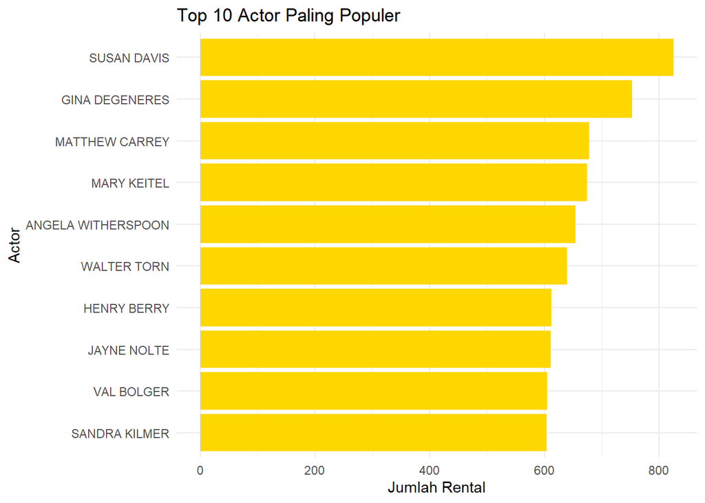

```r
top_actor <- actor_data %>%
  arrange(desc(total_rental)) %>%
  head(10)

p1 <- ggplot(top_actor,
             aes(x = reorder(actor_name, total_rental),
                 y = total_rental)) +
  geom_col(fill = "gold") +
  coord_flip() +
  labs(
    title = "Top 10 Actor Paling Populer",
    x = "Actor",
    y = "Jumlah Rental"
  ) +
  theme_minimal()

p1
```

# Interpretasi Visualisasi 1

Visualisasi menunjukkan actor dengan jumlah rental tertinggi pada database Sakila. Actor dengan jumlah rental tinggi menunjukkan bahwa film-film yang dibintangi actor tersebut lebih sering dipilih pelanggan.

# Visualisasi 2 - Revenue Actor

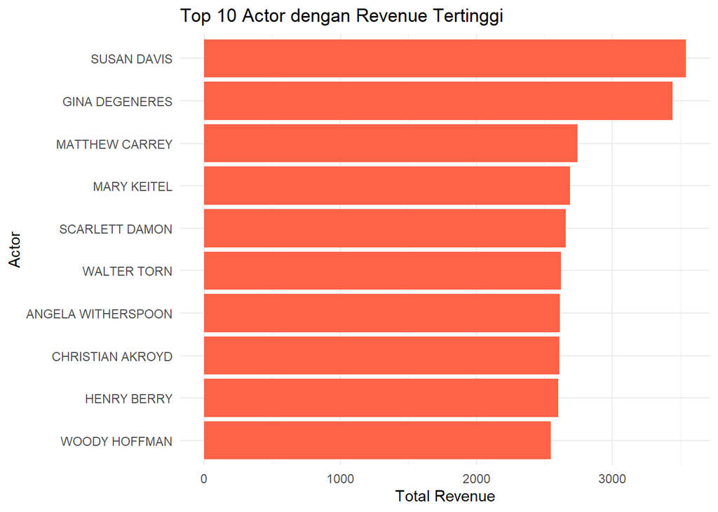

```r
top_revenue <- actor_data %>%
  arrange(desc(total_revenue)) %>%
  head(10)

p2 <- ggplot(top_revenue,
             aes(x = reorder(actor_name, total_revenue),
                 y = total_revenue)) +
  geom_col(fill = "tomato") +
  coord_flip() +
  labs(
    title = "Top 10 Actor dengan Revenue Tertinggi",
    x = "Actor",
    y = "Total Revenue"
  ) +
  theme_minimal()

p2
```

# Interpretasi Visualisasi 2

Beberapa actor menghasilkan revenue yang lebih tinggi dibanding actor lainnya. Hal ini menunjukkan bahwa film yang dibintangi actor tersebut memberikan kontribusi besar terhadap pendapatan bisnis rental film.

# Visualisasi 3 - Hubungan Jumlah Film dan Popularitas

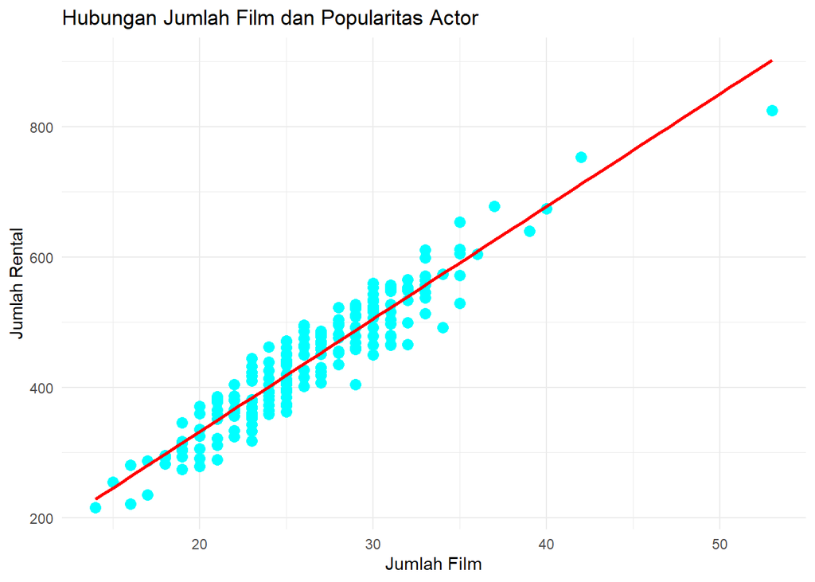

```r
p3 <- ggplot(actor_data,
             aes(x = total_film,
                 y = total_rental)) +
  geom_point(color = "cyan", size = 3) +
  geom_smooth(method = "lm", se = FALSE, color = "red") +
  labs(
    title = "Hubungan Jumlah Film dan Popularitas Actor",
    x = "Jumlah Film",
    y = "Jumlah Rental"
  ) +
  theme_minimal()

p3
```

# Interpretasi Visualisasi 3

Scatter plot menunjukkan hubungan antara jumlah film yang dibintangi actor dengan jumlah rental yang diperoleh. Garis regresi digunakan untuk melihat kecenderungan hubungan antar variabel.

# Analisis Korelasi

```r
correlation <- cor(actor_data$total_film,
                   actor_data$total_rental)

correlation
```

```
## [1] 0.9425585
```

# Interpretasi Korelasi

Nilai korelasi digunakan untuk melihat kekuatan hubungan antara jumlah film actor dan total rental.

- Nilai mendekati 1 menunjukkan hubungan positif kuat.
- Nilai mendekati 0 menunjukkan hubungan lemah.
- Nilai negatif menunjukkan hubungan berlawanan arah.

# Visualisasi Interaktif

```r
ggplotly(p1)
```

[interactive chart not shown]

# Kesimpulan

Berdasarkan hasil analisis pada database Sakila dapat disimpulkan bahwa:

1. Terdapat actor yang memiliki popularitas rental jauh lebih tinggi dibanding actor lainnya.
2. Actor dengan jumlah rental tinggi cenderung menghasilkan revenue besar.
3. Jumlah film actor memiliki hubungan terhadap tingkat popularitas rental.

Analisis ini menunjukkan bahwa actor dapat menjadi salah satu faktor penting dalam preferensi pelanggan terhadap film rental.

# Penutup

Analisis data menggunakan database Sakila dapat membantu memahami pola bisnis rental film dan perilaku pelanggan melalui pendekatan visualisasi dan statistik.